# Lab 1&2

Tomasz Martyński

03.11.2025

# Laboratorium 1

## Zadanie 7.1

```r
n1=50
x_n1=1/(1:n1)
y_n1=sum(x_n1)-log(n1)

n2=100
x_n2=1/(1:n2)
y_n2=sum(x_n2)-log(n2)

n3=1000
x_n3=1/(1:n3)
y_n3=sum(x_n3)-log(n3)

results=list("n=50"=y_n1, "n=100"=y_n2, "n=1000"=y_n3)
results
```

```
## $`n=50`
## [1] 0.5871823
##
## $`n=100`
## [1] 0.5822073
##
## $`n=1000`
## [1] 0.5777156
```

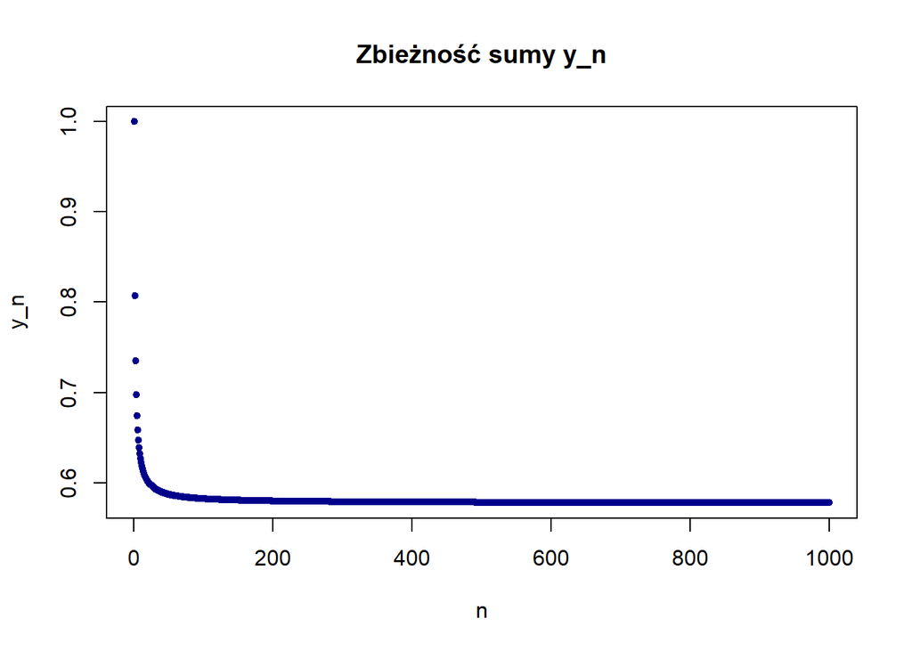

```r
y_n=function(n){
  sum(1/(1:n))-log(n)
}

x=1:1000
y=sapply(x, y_n)

plot(x, y,
     type="p",
     col="blue4",
     main="Zbieżność sumy y_n",
     xlab="n",
     ylab="y_n",
     pch=20 #full dots
)
```

## Zadanie 7.3

```r
#1
x=runif(50)

#2
#y=round(x) - it works
y=numeric(50)
y[x>=0.5]=1
y
```

```
##  [1] 0 1 0 0 0 0 1 0 1 0 1 1 1 0 1 0 0 0 1 0 1 0 0 0 0 0 0 1 0 1 1 0 0 0 1 0 0 1
## [39] 1 1 1 0 1 1 1 0 1 0 1 1
```

```r
#3
counter=sum(y)
avg=counter/50
counter
```

```
## [1] 23
```

```r
avg
```

```
## [1] 0.46
```

```r
#general case
fun=function(n){
  x_n=runif(n)
  y_n=numeric(n)
  y_n[x_n>=0.5]=1

  results_n=list(one_counter=sum(y_n),  one_to_all_proportion=sum(y_n)/n)
  return(results_n)
}


fun(400)
```

```
## $one_counter
## [1] 191
##
## $one_to_all_proportion
## [1] 0.4775
```

```r
fun(5000)
```

```
## $one_counter
## [1] 2520
##
## $one_to_all_proportion
## [1] 0.504
```

```r
fun(200000)
```

```
## $one_counter
## [1] 100103
##
## $one_to_all_proportion
## [1] 0.500515
```

Średnia liczba wylosowanych wartości nie mniejszych niż $0,5$ kręci się wokół $50%$ wszystkich wyników, co zgadza się z intuicją, gdyż rozkład $x_i$ jest jednostajny (połowa wartości powinna być większa niż $0,5$).

## Zadanie 7.5

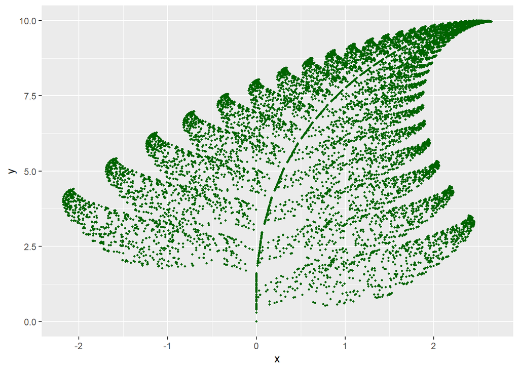

```r
library("ggplot2")
n=10000

r=sample(x=c(1,2,3,4), size=n, replace=TRUE, prob=c(0.85, 0.07, 0.07, 0.01))

x=numeric(n+1)
y=numeric(n+1)

for (i in 1:n){
  if (r[i]==1){
    x[i+1]=0.85*x[i]+0.04*y[i]
    y[i+1]=-0.04*x[i]+0.85*y[i]+1.6
  }else if (r[i]==2){
    x[i+1]=-0.15*x[i]+0.28*y[i]
    y[i+1]=0.26*x[i]+0.24*y[i]+0.44
  }else if (r[i]== 3){
    x[i+1]=0.2*x[i]-0.26*y[i]
    y[i+1]=0.23*x[i]+0.22*y[i]+1.6
  }else{
    x[i+1]=0
    y[i+1]=0.16*y[i]
  }
}


df=data.frame(x,y)
ggplot(df)+geom_point(aes(x,y), color="darkgreen",size=0.8)
```

## Zadanie 7.7.1

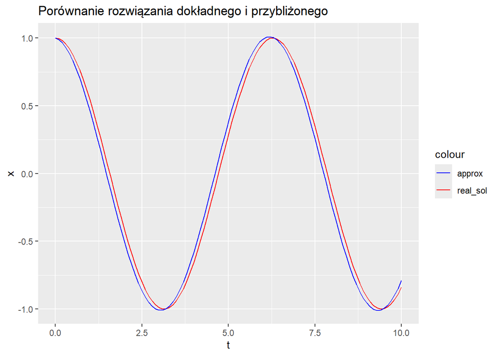

```r
t_0=0
T=10
N=100
h=(T-t_0)/N
eta=1

diff_eq=function(t,x){
  -5*(x-cos(t))-sin(t)
}

t=seq(t_0, T, length.out=N+1)

x_appr=numeric(N+1)
x_appr[1]=eta

for (k in 1:N){
  x_k=x_appr[k]
  t_k=t_0+h*k
  x_appr[k+1]=x_k+h*diff_eq(t_k,x_k)
}

df=data.frame(t,cos(t))

ggplot(df, aes(x = t, y = cos(t), color="real_sol")) + geom_line()+
  geom_line(aes(x=t, y=x_appr, color="approx"))+
  scale_color_manual(values=c("real_sol"="red", "approx"="blue"))+
  labs(title="Porównanie rozwiązania dokładnego i przybliżonego",x="t", y="x")
```

## Zadania 8.1

### Zadanie 8.1.1

Zwiększamy dokładność za pomocą argumentu control (typu lista), który zawiera parametr “ftol” - tolerancja błędu funkcji, czyli residuum. Wystarczy dopisać w linijce rozw:

rozw=nleqslv(xstart, dslnex, jac=jacdsln, **control=list(ftol=1e-12**))

(tu wziąłem dokładność na poziomie $10^{-12}$, czyli 1000 razy większą, niż pierwotnego residuum)

### Zadanie 8.1.2

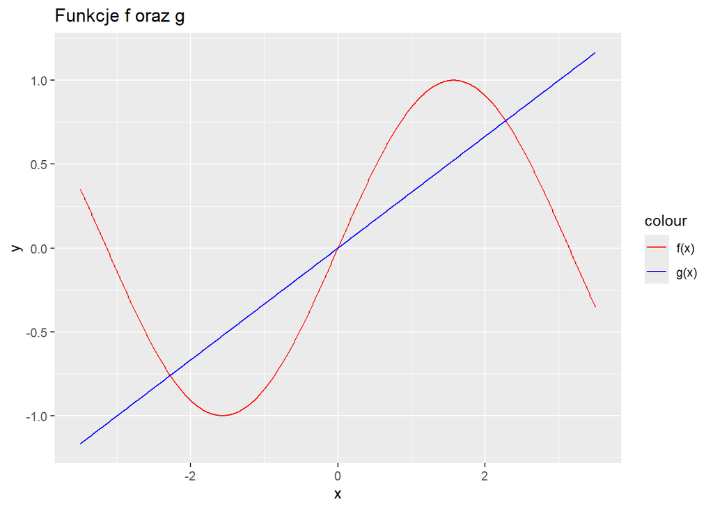

```r
#1
x=seq(-3.5,3.5, length.out=1000)

df=data.frame(x,sin(x))

ggplot(df, aes(x = x, y = sin(x), color="f(x)")) + geom_line()+
  geom_line(aes(x=x, y=x/3, color="g(x)"))+
  scale_color_manual(values=c("f(x)"="red", "g(x)"="blue"))+
  labs(title="Funkcje f oraz g",x="x", y="y")
```

```r
#2
library("nleqslv")

dslnex=function(x){
  y=sin(x)-x/3
  y
}

jacdsln=function(x){
  Df=cos(x)-1/3
  Df
}

#punkty startowe - jeden dodatni, jeden ujemny, szacuję na oko za pomocą wykresu
xstart_plus=2.2
xstart_minus=-2.2

rozw_plus=nleqslv(xstart_plus, dslnex, jac=jacdsln, control=list(ftol=1e-12))
rozw_minus=nleqslv(xstart_minus, dslnex, jac=jacdsln, control=list(ftol=1e-12))

rozw_minus$x
```

```
## [1] -2.278863
```

```r
rozw_plus$x
```

```
## [1] 2.278863
```

# Laboratorium 2

## Zadanie 2.1 - artykuł o całce Riemanna

### Geneza

Nazwa pochodzi od niemieckiego matematyka Bernharda Riemanna, który przedstawił tę koncepcję w 1854 roku w swojej pracy habilitacyjnej pt. *Über die Darstellbarkeit einer Funktion durch eine trigonometrische Reihe* („O reprezentowalności funkcji przez szereg trygonometryczny”) na Uniwersytecie w Getyndze. Była to pierwsza ścisła definicja całki. Istnieje również całkowicie równoważna całce Riemanna konstrukcja całki Darboux, pochodząca od francuskiego matematyka Gastona Darboux, który wprowadził ją w swojej pracy z 1870 roku zatytułowanej *Sur les équations aux dérivées partielles du second ordre* („O równaniach różniczkowych cząstkowych drugiego rzędu”) i uzasadnił jej równoważność z całką Riemanna w 1875 roku w pracy pt. *Mémoire sur la theorie des fonctions discontinues* („Rozprawa o teorii funkcji nieciągłych”).

#### Zalety i wady tej całki

Głównymi zaletami całki Riemanna są intuicyjność, klarowność definicji i stosunkowa łatwość wprowadzenia wystarczające częstokroć do większości zastosowań praktycznych; konstrukcja Darboux wymaga nieco mniejszej liczby pojęć niezbędnych do jej przeprowadzenia, przez co stanowi atrakcyjną alternatywę dla konstrukcji Riemanna.

Do zasadniczych wad tych całek należy względnie mała ilość funkcji całkowalnych, czy konieczność zbieżności jednostajnej ciągu funkcji przy zamianie operatorów granicy i całki, co znacząco zawęża zakres zastosowań teoretycznych. Istnieje wiele uogólnień tego pojęcia mających na celu pokonanie różnorakich jego ograniczeń.

### Definicja całki

Jeżeli dla każdego normalnego ciągu $(Δn)^∞_{n=1}$ podziałów przedziału $[a,b]$ ciąg $(S_n)^∞_{n=1}$ $n$-tych sum całkowych Riemanna jest zbieżny do tej samej granicy właściwej, niezależnej od wyboru punktów pośrednich $\xi _k$ dla $(k=1,\ldots,n)$, to granicę tę nazywamy całką oznaczoną Riemanna funkcji $f$ na przedziale $[a,b]$ i oznaczamy symbolem $\int_{a}^{b} f(x)dx$, tzn.
$$\int_{a}^{b}
f(x)dx:=\lim_{n\to\infty}S_n.$$

[figure not shown]

### Źródła

[Wikipedia](https://pl.wikipedia.org/wiki/Ca%C5%82ka_Riemanna)

[Open AGH Podręczniki](https://epodreczniki.open.agh.edu.pl/handbook/7/module/83/reader)